# Przykłady i rozwiązania

Michał Burdukiewicz

31-05-2026

Źródło danych: https://github.com/michbur/polish-driver-license

## Rysunek 1

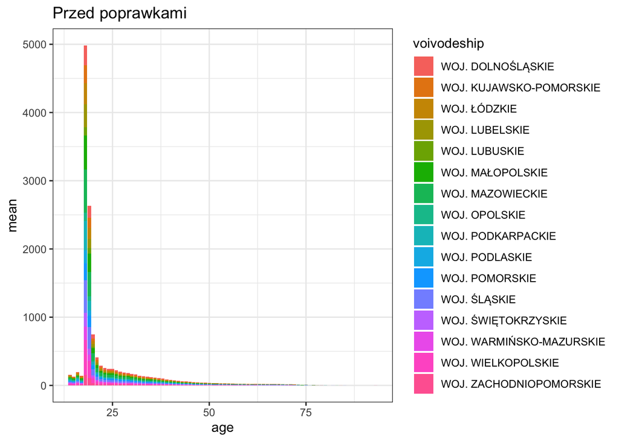

Cel: pokazanie średniej liczby osób, które uzyskały prawo jazdy w danym wieku w zależności od województwa.

Zmiany:

Atrybuty wizualne: oś x - wiek oś y - średnia (bez zmian) Geometrie: wykres słupkowy ale bez wartości skumulowanych Facety: podział na 16 mniejszych wykresów (jeden wykres = jedno województwo) Statystyki:

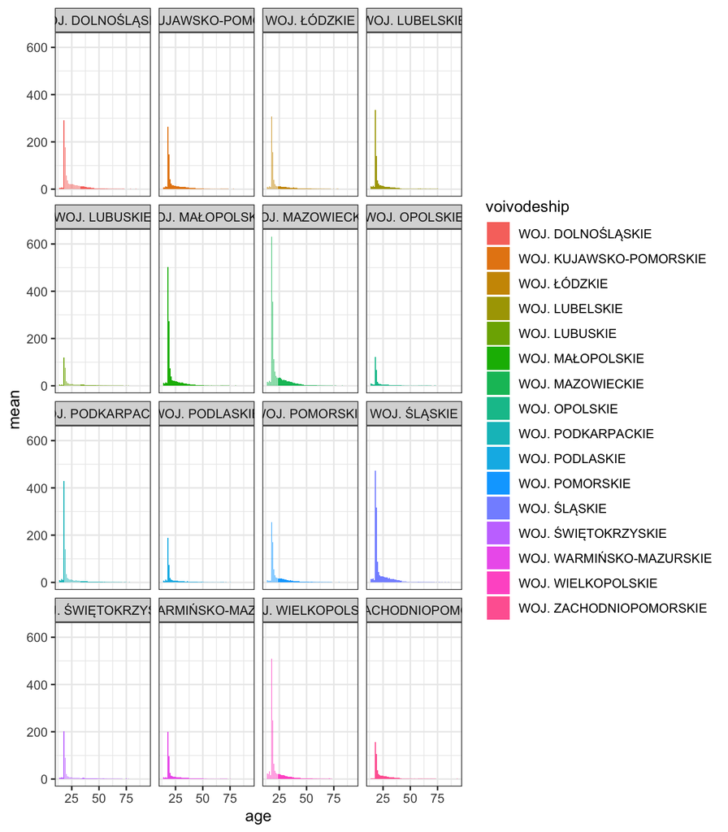

```
## <ggplot2::labels> List of 1
##  $ title: chr "Po poprawkach"
```

## Rysunek 2

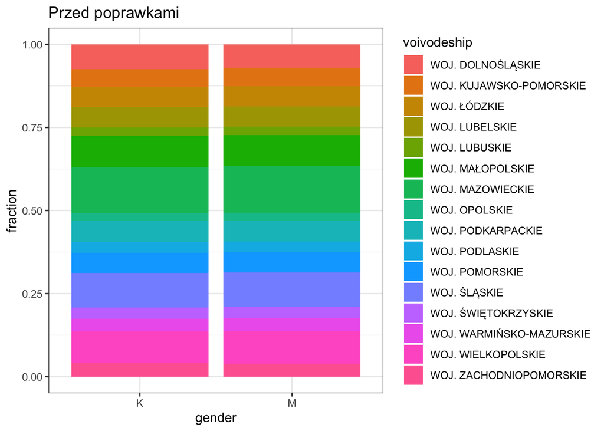

Cel: pokazanie frakcji kobiet i mężczyzn uzyskujących prawo jazdy w danym województwie.

Zmiany:

Atrybuty wizualne: opcja 1: oś x - województwa oś y - frakcja kobiet i mężczyzn opcja 2: oś x - województwa i dodatkowy podział na kobiety i mężczyzn oś y - faktyczna liczebność lub frakcja kobiet i mężczyzn

użycie dwóch kolorów (kobiety i mężczyźni), np. niebieski i pomarańczowy

Geometrie: wykres słupkowy (skumulowany dla opcji 1, zwykły dla opcji 2)

Facety: dla każdego województwa osobna faseta (16 osobnych wykresów) (dla opcji 2)

Statystyki: udział procentowy kobiet i mężczyzn dla danego województwa

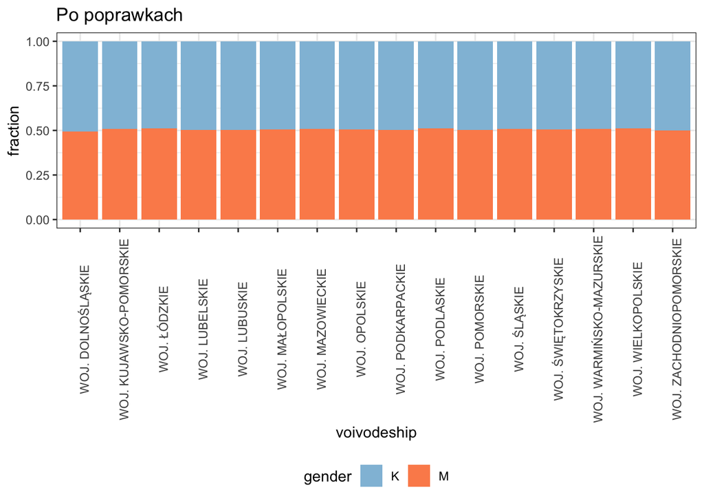

## Rysunek 3

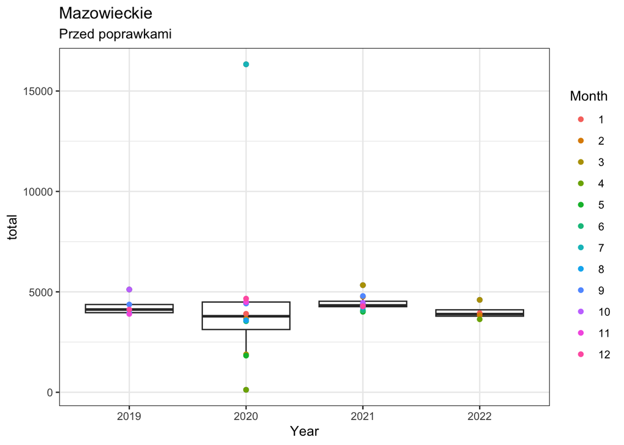

Cel: pokazanie zmienności liczby uzyskanych praw jazdy w skali roku w zależności od roku w województwie mazowieckim.

Atrybuty wizualne: Osie: linie ciągłe w kolorze czarnym Oś X: miesiące Oś Y: total Tytuł wykresu: Liczba wydanych praw jazdy w XXXX roku w woj. Mazowieckim Wykres liniowy z punktami odpowiadającymi miesiącom w tym samym kolorze co krzywa dla danego roku

Geometrie: Wykres liniowy z punktami odpowiadającymi miesiącom Facety: 4 oddzielne wykresy liniowe pokazujace zmienność danych w danym roku

Statystyki: Brak Koordynaty: Układ kartezjański

Motyw: Wykres na białym tle

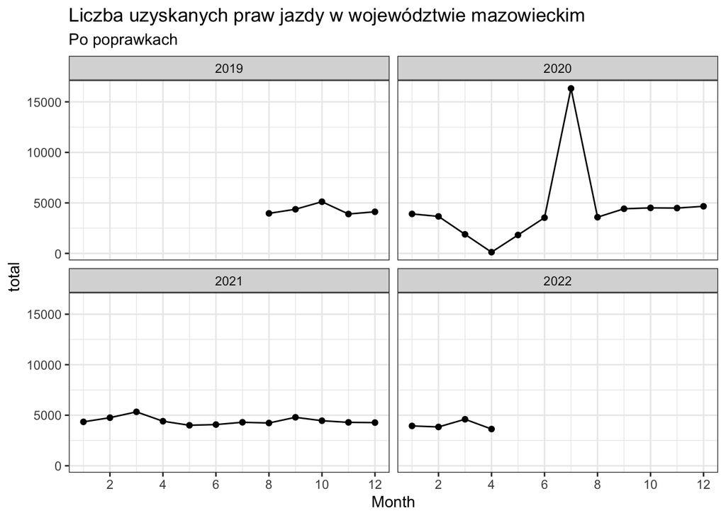

## Rysunek 4

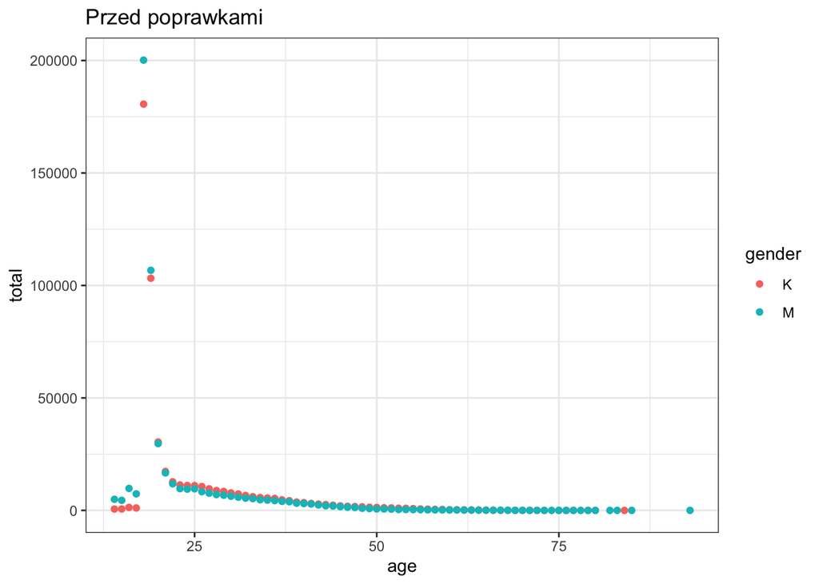

Cel: pokazać zależność liczby uzyskanych praw jazdy w zależności od wieku i płci.

Zmiany:

Facety: brak Statystyki: suma,

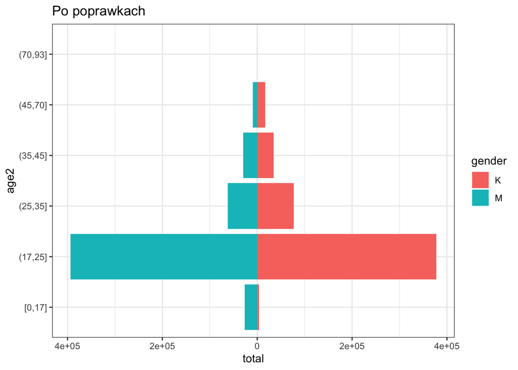

## Rysunek 5

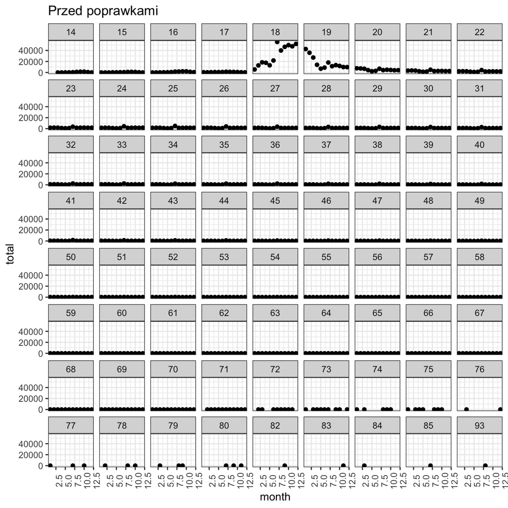

Cel: pokazać liczbę praw jazdy uzyskiwanych przez osoby w różnym wieku w zależności od miesiąca.

Zmiany: osobne wykresy dla grup wiekowych 14–17(nastolatkowie), 18–25(młodzi dorośli), 26–45(dorosły), 46–65(starsi dorośli), 65-93(seniorzy), oś y liczba praw jazdy (dopasowanie skali dla każdego wykresu do maksimum danych), oś x miesiące

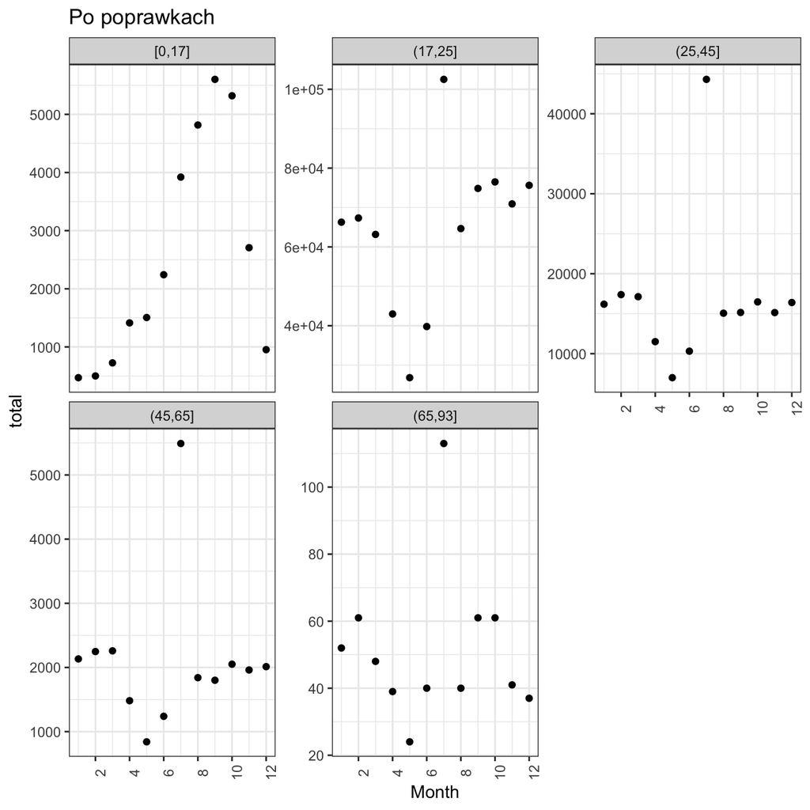

## Rysunek 6

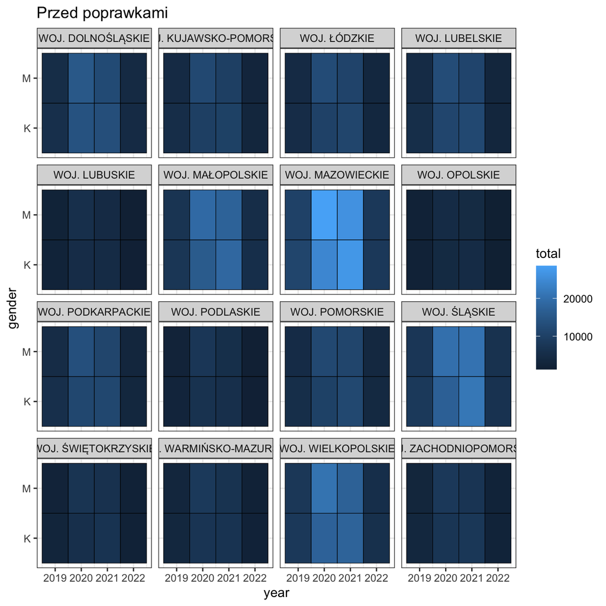

Cel: pokazać liczbę uzyskanych praw jazdy dla poszczególnych województw w zależności od płci i roku.

Zmiany:

Atrybuty wizualne: oś X: rok, oś Y: linia ciągła: liczba praw jazdy, kolor: płeć np. niebieski vs czerwony legenda: kolor lini vs płeć opisy osi: np. data[rok], płeć[m, k] opisy facetów: b/z tytuł wykresu: “Liczba uzyskanych praw jazdy w zależności od płci i roku.” Geometrie: linie łączące punkty w czasie, wyraźny punkt na przecięciu linii, siatka -> linia przerywana, wyszarzona Facety: podział na województwa -> siatka mniejszych wykresów -> osobny panel na każde woj. skala: wspólny początek OY i OX. Jeżeli linie będą się nakładać -> wykres słupkowy lub zmniejszenie skali Statystyki: brak. zostaje: ilość ze względu na płeć / rok

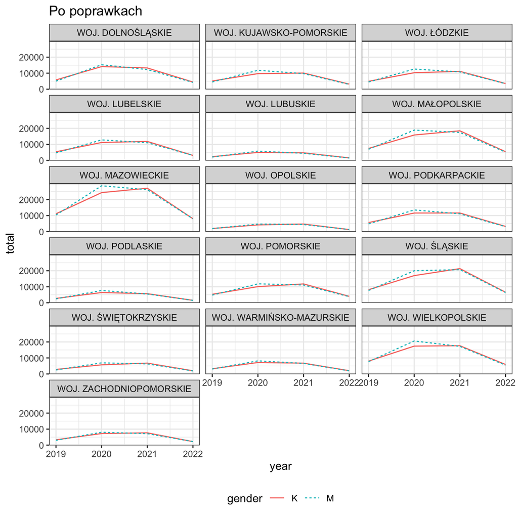